# R Notebook

```r
maisVelho <- function(Pessoa1, Pessoa2) {
  if (is.numeric(Pessoa1)&is.numeric(Pessoa2)) {
      if (Pessoa1 > Pessoa2) {
        cat("A pessoa 2 é mais velha que a pessoa 2", "\n")
      } else if (Pessoa1 < Pessoa2) {
        cat("A pessoa 1 é mais nova que a pessoa 2", "\n")
      } else {
        cat("As idades das pessoas são iguais","\n")
      }
  } else {
      print ("Algum dos valores não é numero, tente de novo")
  }

  # Check for integer with %% operator
  # x=is.integer(Pessoa1)
  #x=5
  #return = print(x)
}
maisVelho(1.5,"A")
```

```
[1] "Algum dos valores não é numero, tente de novo"
```

Exercício 2 BOD é um objeto existente no R. Verifique qual a classe deste objeto.

```r
typeof(BOD)
```

```
[1] "list"
```

Exercício 3. Crie um vetor que armazene números de 1 a 10 e posteriormente imprima os valores pares.

```r
x = seq(1,10,1)
x=as.list(x)
for (n in x){
  if(x[[n]] %% 2 == 0){print(x[[n]])}
}
```

```
[1] 2
[1] 4
[1] 6
[1] 8
[1] 10
```

4. women é um dataframe existente no R. Imprima as 10 últimas linhas

```r
tail(women,10)
```

|  | height | weight |
| --- | --- | --- |
| 6 | 63 | 129 |
| 7 | 64 | 132 |
| 8 | 65 | 135 |
| 9 | 66 | 139 |
| 10 | 67 | 142 |
| 11 | 68 | 146 |
| 12 | 69 | 150 |
| 13 | 70 | 154 |
| 14 | 71 | 159 |
| 15 | 72 | 164 |

```r
NA
```

5. Use a função plot do R para produzir um gráfico do atributos Sepal.Width e Petal.Length do conjunto de dados Iris. O gráfico deve imprimir apenas das linhas 50 até 100.

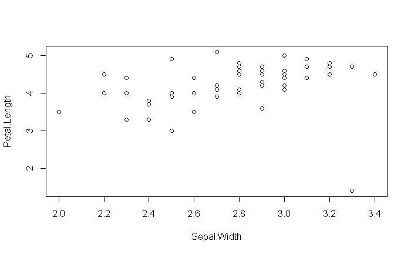

```r
#head(x = iris) #,[["Sepal.Width","Petal.Length"]]
x = iris
#head(x)
plot(x[, c("Sepal.Width", "Petal.Length")][50:100,])
```

```r
NA
NA
```

6. Crie dois vetores de tamanhos iguais, some as posições equivalentes dos vetores e imprima o resultado.

```r
x = seq(1,10,1)
y = seq(1,20,2)
z=x+y
z
```

```
 [1]  2  5  8 11 14 17 20 23 26 29
```

7. Imprima o número de linhas, de colunas, nomes das linhas e nome das colunas do conjunto de dados CO2.

```r
y=dim(x=CO2)
y
```

```
[1] 84  5
```

```r
cat("Linhas: ",y[1]," Colunas: ",y[2],"\n","Nomes Linhas: ",rownames(CO2),"\n","Nomes Colunas: ",colnames(CO2))
```

```
Linhas:  84  Colunas:  5
 Nomes Linhas:  1 2 3 4 5 6 7 8 9 10 11 12 13 14 15 16 17 18 19 20 21 22 23 24 25 26 27 28 29 30 31 32 33 34 35 36 37 38 39 40 41 42 43 44 45 46 47 48 49 50 51 52 53 54 55 56 57 58 59 60 61 62 63 64 65 66 67 68 69 70 71 72 73 74 75 76 77 78 79 80 81 82 83 84
 Nomes Colunas:  Plant Type Treatment conc uptake
```

Sandbox: Testa se é inteiro: if ((Pessoa1 %% 1 != 0)|(Pessoa2 %% 1 != 0)) x=is.integer(Pessoa1)